#### CMSC 320

#### Final Project: Mass Shootings Analysis

### Goals:

- To create a tutorial that will walk users through the entire data science pipeline: data curation, parsing, and management; exploratory data analysis; hypothesis testing and machine learning to provide analysis; and then the curation of a message or messages covering insights learned during the tutorial.

### Overview:

This tutorial will be an analysis of The Stanford Mass Shootings of America (MSA) data along with population data by state.

The Stanford MSA is a data aggregation effort. It is a curated set of spatial and temporal data about mass shootings in America, taken from online media sources. It is an attempt to facilitate research on gun violence in the US by making raw data more accessible.

### Libraries and Data:

The libraries we will use are:

- tidyverse
- dplyr
- stringr
- ggplot2

The following code imports the libraries and loads the dataset:

```r
# libraries
library(tidyverse, quietly=TRUE, warn.conflicts=FALSE)
library(dplyr, quietly=TRUE, warn.conflicts=FALSE)
library(stringr, quietly=TRUE, warn.conflicts=FALSE)
library(ggplot2, quietly=TRUE, warn.conflicts=FALSE)

# data
msa <- read_csv("stanford_shooting_data.csv")
pop <- read_csv("us_state_populations.csv")
```

### Data Wrangling, Tidying, & Management:

The shooting data we have now contains a lot of descriptions about the shootings. These are text descriptions and cannot be used in any statistical analysis. They will not be used in this tutorial so we can remove them to create a smaller subset of relevant data.

```r
# select specific attributes
data <- msa %>%
  select(CaseID, Date, City, State, Latitude, Longitude,
         `Total Number of Fatalities`, `Average Shooter Age`,
         `Shooter Sex`, `Shooter Race`, `School Related`,
         `Place Type`, `Relationship to Incident Location`,
         `Fate of Shooter`, `Possible Motive - General`,
         `History of Mental Illness - General`)

data
```

```
## # A tibble: 335 x 16
##    CaseID Date   City    State   Latitude Longitude `Total Number of … `Average Shoote… `Shooter Sex` `Shooter Race`
##     <int> <chr>  <chr>   <chr>      <dbl>     <dbl>              <int> <chr>            <chr>         <chr>
##  1      1 8/1/1… Austin  Texas       30.2    - 97.8                 16 25               Male          White American o…
##  2      2 11/12… Mesa    Arizona     33.4    -112                    5 18               Male          White American o…
##  3      3 12/31… New Or… Louisi…     30.1    - 89.9                 10 23               Male          Black American o…
##  4      4 1/17/… Chicago Illino…     41.8    - 87.7                  1 14               Male          Unknown
##  5      5 12/30… Olean   New Yo…     42.1    - 78.4                  3 17               Male          White American o…
##  6      6 2/19/… Los An… Califo…     34.2    -119                    1 18               Male          White American o…
##  7      7 7/12/… Fuller… Califo…     33.9    -118                    7 37               Male          White American o…
##  8      8 1/29/… San Di… Califo…     32.9    -117                    2 16               Female        White American o…
##  9      9 10/6/… Columb… South …     34.1    - 80.8                  2 19               Male          Black American o…
## 10     10 3/19/… Las Ve… Nevada      36.2    -115                    1 17               Male          White American o…
## # ... with 325 more rows, and 6 more variables: `School Related` <chr>, `Place Type` <chr>, `Relationship to Incident
## #   Location` <chr>, `Fate of Shooter` <chr>, `Possible Motive - General` <chr>, `History of Mental Illness -
## #   General` <chr>
```

The column names are not easy to use as they contain whitespace. Let’s rename them.

```r
# rename cols
names(data) <- c("case_id", "date", "city", "state", "lat",
                 "long", "num_fatalities", "avg_shooter_age",
                 "shooter_sex", "shooter_race", "school_related",
                 "place", "relationship", "shooter_fate",
                 "motive", "mental_illness")
```

The exact date of each incident is irrelevant to us since we will only use the year in this analysis. Let’s extract the year using regular expressions and rename the date column.

```r
# extract year
data$date <- str_extract(data$date, regex("\\d{4}"))

# rename col
names(data)[names(data) == "date"] <- "year"
```

Another issue right now in both datasets is the state name. They are not abbreviated so they will crowd our plots, especially the axes. We can change the state names to their proper abbreviations easily by doing the following:

```r
# abbreviate states
data$state <- state.abb[match(data$state, state.name)]
pop$state <- state.abb[match(pop$state, state.name)]
```

### Analysis: Shootings by Location

Now that we have a usable data set, we can perform some analysis. Let’s analyze shootings by location. With this analysis, we will be able to see if some states have more shootings than others.

Here is a plot to visualize mass shootings across location:

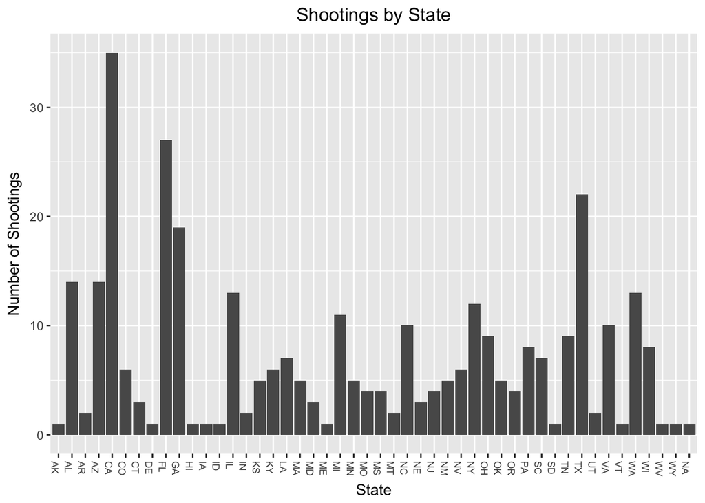

```r
# plot shootings by state
shootings_by_state <- data %>%
    ggplot(aes(state)) +
    geom_histogram(stat="count") +
    theme(axis.text.x=element_text(size=7, angle=-90, hjust=0),
          plot.title=element_text(hjust=0.5)) +
    labs(title="Shootings by State", x="State", y="Number of Shootings")

shootings_by_state
```

From this histogram we can see that the most mass shootings occur in California. This is consistent to findings from other sources. It also makes sense since CA has the largest population of any state in the US, meaning we can expect more shootings to occur in CA compared to the rest of the states.

### Analysis: Shootings Per Capita

We can normalize the data by computing the number of shootings per capita within each state. We will use the pop dataframe to compute the frequency of shootings by state.

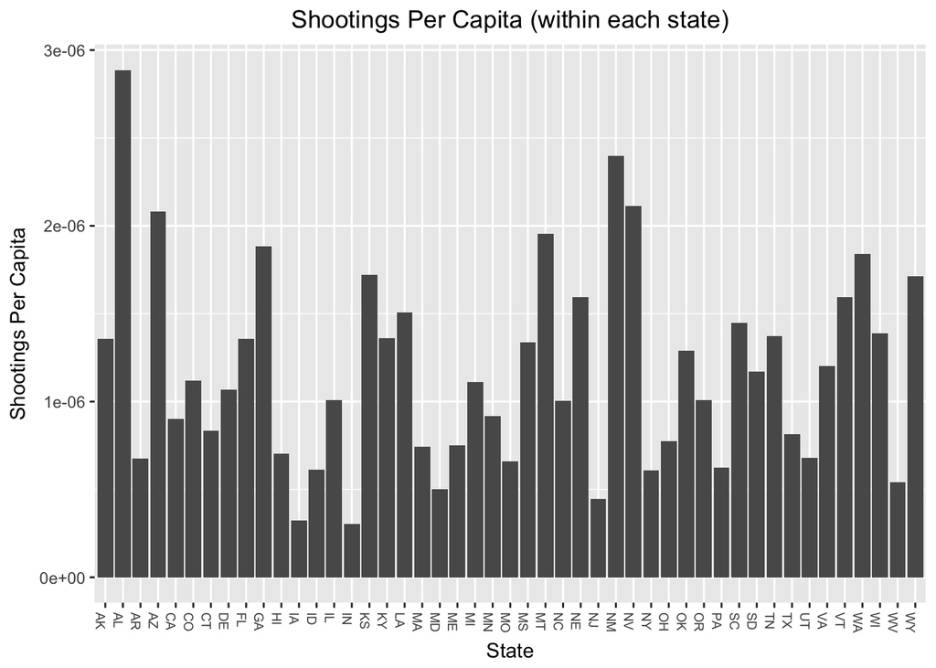

```r
# rename col
names(pop)[names(pop) == "pop_est_2014"] <- "population"

# make frequency table
frequencies <- as.data.frame(table(data$state))
names(frequencies) <- c("state", "frequency")
frequencies <- merge(frequencies, pop, by="state")

# calculate shootings per capita
frequencies$shootings_per_capita <- frequencies$frequency / frequencies$population

# plot
shootings_per_capita <-
    ggplot(data=frequencies, aes(x=state, y=shootings_per_capita)) +
    geom_histogram(stat="identity") +
    theme(axis.text.x=element_text(size=7, angle=-90, hjust=0),
          plot.title=element_text(hjust=0.5)) +
    labs(title="Shootings Per Capita (within each state)", x="State", y="Shootings Per Capita")

shootings_per_capita
```

This is much more useful than the original plot. We can now see that even though California has the most mass shootings in count, it is about average in shootings per capita. Other states like Alabama and Nevada have much higher numbers of shootings per capita, while states such as Iowa and Indiana have low numbers. This normalized plot is much better to see how mass shootings are correlated by state.

### Analysis: Gender and Race of Shooters

To follow shootings by state, let’s take a look at shootings by the shooter’s gender and race. This will help us see what proportion of shooters are men and what proportion are women along with their race.

Let’s make a plot of shootings by gender first:

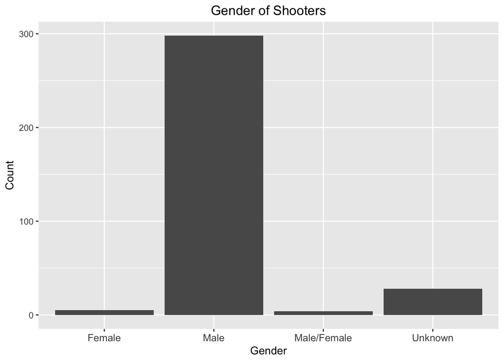

```r
# shootings by gender plot
 gender_of_shooter <- data %>%
    ggplot(aes(shooter_sex)) +
    geom_histogram(stat="count") +
    theme(axis.text.x=element_text(size=10),
          plot.title=element_text(hjust=0.5)) +
    labs(title="Gender of Shooters", x="Gender", y="Count")

gender_of_shooter
```

We can see that the almost all shooters are men. There is roughly the same amount of shootings by female shooters as there are shootings committed by multiple shooters consisting of both men and women.

We will now make the same plot but with race instead of gender:

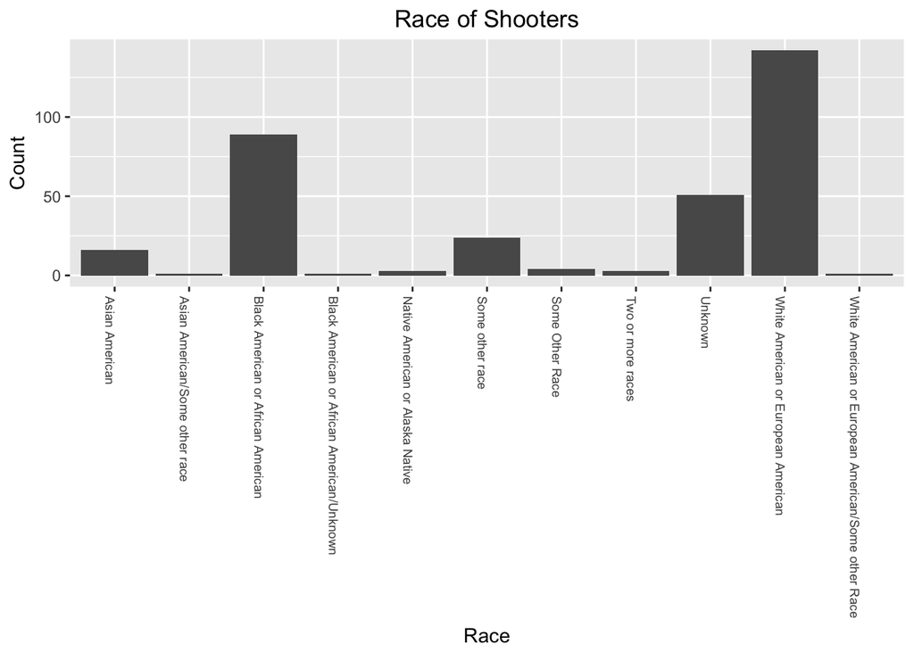

```r
# shootings by race plot
 shooter_race <- data %>%
    ggplot(aes(shooter_race)) +
    geom_histogram(stat="count") +
    theme(axis.text.x=element_text(size=7, angle=-90, hjust=0),
          plot.title=element_text(hjust=0.5)) +
    labs(title="Race of Shooters", x="Race", y="Count")

  shooter_race
```

Let’s now take a look at the fate of the shooter. In all cases, the shooter either gets taken into custody, gets killed, or escapes. Let’s make a plot to show this distribution:

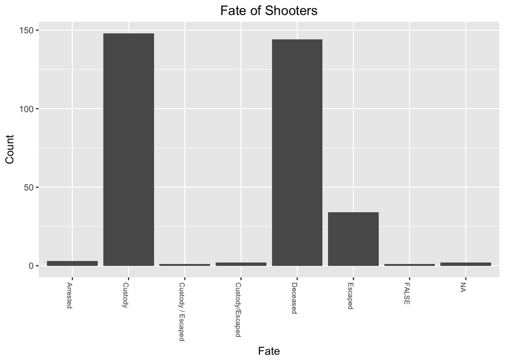

```r
# fate of shooter plot
 shooter_fate <- data %>%
    ggplot(aes(shooter_fate)) +
    geom_histogram(stat="count") +
    theme(axis.text.x=element_text(size=7, angle=-90, hjust=0),
          plot.title=element_text(hjust=0.5)) +
    labs(title="Fate of Shooters", x="Fate", y="Count")

  shooter_fate
```

We see that shooters get killed just about as often as they get taken into custody. We aslo see that only a small portion are able to escape.

### Hypothesis Testing: High Risk States

The question: Is the difference between the number of fatalities and number of shootings in California significantly significant to that of Texas? This will allow us to see which city has more fatalities per shooting on average. It will be interesting since these are two of the largest states in the country.

Our null hypothesis is that the number of fatalities and shootings is not statistically significant between California and Texas. Our alternative hypothesis will be that the number of fatalities and shootings is lower in California than Texas.

We will reject the null hypothesis if alpha is less the 0.05 (a < 0.05).

The pt() function will be used to find our p-value. We perform a t-statistic and calculate degrees of freedom after some computation:

We first need to get the necessary information:

```r
# get number of fatalities per city
fatalities_shootings <- group_by(data, state, city) %>%
  mutate(total_fatalities = sum(num_fatalities)) %>%
  mutate(total_shootings = n()) %>%
  select(state, total_fatalities, total_shootings) %>%
  distinct()

fatalities_shootings
```

```
## # A tibble: 252 x 4
## # Groups:   state, city [252]
##    city        state total_fatalities total_shootings
##    <chr>       <chr>            <int>           <int>
##  1 Austin      TX                  17               2
##  2 Mesa        AZ                   6               2
##  3 New Orleans LA                  11               4
##  4 Chicago     IL                  18               7
##  5 Olean       NY                   3               1
##  6 Los Angeles CA                   8               5
##  7 Fullerton   CA                   7               1
##  8 San Diego   CA                   7               3
##  9 Columbia    SC                   2               1
## 10 Las Vegas   NV                   6               4
## # ... with 242 more rows
```

```r
# total fatalities in CA
cali_fat <- fatalities_shootings$total_fatalities[fatalities_shootings$state=="CA"]
cali_fat <- as.data.frame(cali_fat)
names(cali_fat)[1] <- "to_add"
sum_cali_fat <- sum(cali_fat$to_add, na.rm = TRUE)

# total shootings in CA
cali_shoot <- fatalities_shootings$total_shootings[fatalities_shootings$state=="CA"]
cali_shoot <- as.data.frame(cali_shoot)
names(cali_shoot)[1] <- "to_add"
sum_cali_shoot <- sum(cali_shoot$to_add, na.rm = TRUE)

# total fatalities in TX
tx_fat <- fatalities_shootings$total_fatalities[fatalities_shootings$state=="TX"]
tx_fat <- as.data.frame(tx_fat)
names(tx_fat)[1] <- "to_add"
sum_tx_fat <- sum(tx_fat$to_add, na.rm = TRUE)

# total shootings in TX
tx_shoot <- fatalities_shootings$total_shootings[fatalities_shootings$state=="TX"]
tx_shoot <- as.data.frame(tx_shoot)
names(tx_shoot)[1] <- "to_add"
sum_tx_shoot <- sum(tx_shoot$to_add, na.rm = TRUE)
```

We can now find the mean, standard deviation, and total for each state. This will be used to calculate our t-statistic.

```r
# calculate values for CA
ca_mean <- sum_cali_fat / sum_cali_shoot
ca_sd <- sd(cali_fat$to_add, na.rm = TRUE) / sd(cali_shoot$to_add, na.rm = TRUE)
ca_num <- sum_cali_fat

# calculate values for TX
tx_mean <- sum_tx_fat / sum_tx_shoot
tx_sd <- sd(tx_fat$to_add, na.rm = TRUE) / sd(tx_shoot$to_add, na.rm = TRUE)
tx_num <- sum_tx_fat
```

We can now find our p value by using the pt() function:

```r
# set up the values for the pt() function
t_stat <- (ca_mean-tx_mean)/sqrt(ca_sd^2/ca_num+tx_sd^2/tx_num)
df <- abs(tx_num-ca_num-2)

#calculate the p value
p <- 1 - pt(abs(t_stat), df)
p
```

```
## [1] 0.1469311
```

### Analysis: Machine Learning

Let’s go back to looking at our data more generally. We will consider how deadly the mass shootings were by using the number of fatalities in each shooting. We will create a scatterplot and add a regression line to see if shootings became deadlier over time or simply more frequent.

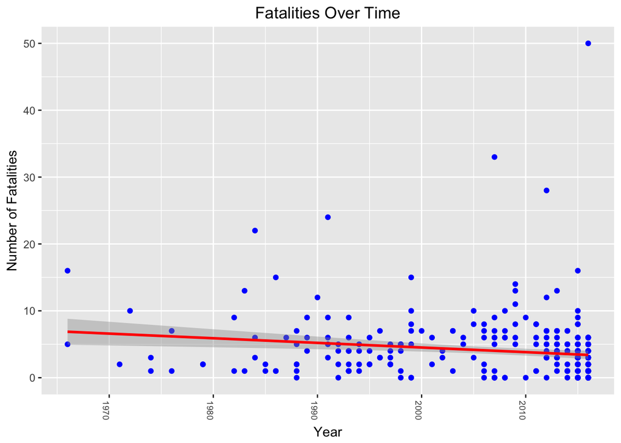

```r
# plot fatalities over time
 fatalities_over_time_reg <- data %>%
    ggplot(aes(x=as.numeric(year), y=as.numeric(num_fatalities))) +
    geom_point(color="blue") +
    geom_smooth(method='lm', color="red") +   # add a linear model
    theme(axis.text.x=element_text(size=7, angle=-90, hjust=0),
          plot.title=element_text(hjust=0.5)) +
    labs(title="Fatalities Over Time", x="Year", y="Number of Fatalities")

fatalities_over_time_reg
```

The graph above shows that fatalities per shooting have decreased slightly over time. It is important to note that although deaths per shooting have decreased, deaths per year have increased. Let’s analyze this further by regressing deaths per shooting on deaths per year.

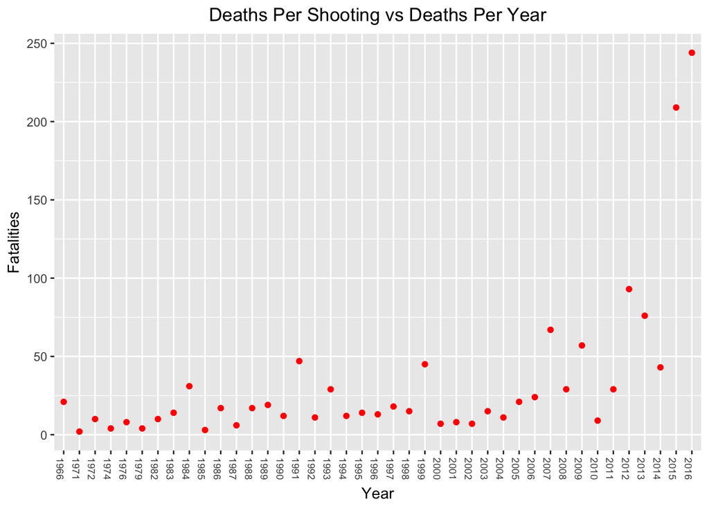

```r
# regress deaths per shooting on deaths per year
fatalities_over_time <- aggregate(num_fatalities ~ year, data, sum)

fatality_regression <- fatalities_over_time %>%
    ggplot(aes(x=year, y=num_fatalities)) +
    geom_point(color="red") +
    geom_smooth(method=lm) +
    theme(axis.text.x=element_text(size=7, angle=-90, hjust=0),
          plot.title=element_text(hjust=0.5)) +
    labs(title="Deaths Per Shooting vs Deaths Per Year", x="Year", y="Fatalities")

fatality_regression
```

This plot shows a positive trend between year and number of fatalities, meaning more deaths have occurred over time.